# Monte Carlo Integration with Control Variates

Nikolai German

2025-07-07

# 1 Introduction

We want to compute the integral $I = \int_0^1 e^x \, dx$, for which we know the true value is $e - 1 \approx 1.718$.

The **control variates** method is a variance reduction technique that uses a correlated function with known expectation to reduce the variance of our Monte Carlo estimator.

Let $f(x) = e^x$ be our target function and $g(x) = x$ be our control variate. We know that: - $\int_0^1 e^x \, dx = e - 1$ (unknown, what we want to estimate) - $\int_0^1 x \, dx = \frac{1}{2}$ (known exactly)

The control variate estimator is:
$$\hat{I}_{CV} = \frac{1}{n}\sum_{i=1}^n f(U_i) -
c\left(\frac{1}{n}\sum_{i=1}^n g(U_i) - \frac{1}{2}\right)$$

where $U_i \overset{i.i.d.}{\sim} \text{Unif}(0, 1)$ and $c$ is chosen to minimize variance:
$$c^* =
\frac{\text{Cov}(f(U), g(U))}{\text{Var}(g(U))}$$

# 2 Visualization of Control Variates Method

The following code demonstrates how the control variate method works:

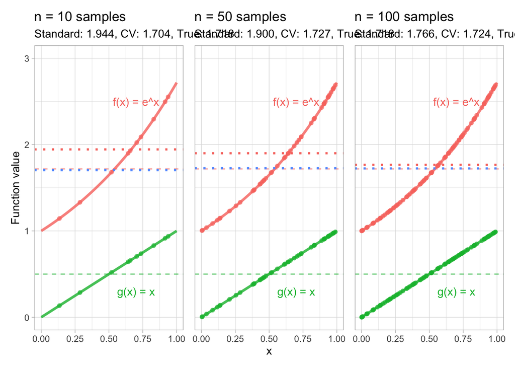

```r
# Target function and control variate
f_target <- function(x) exp(x)
g_control <- function(x) x

# True values
true_f <- exp(1) - 1  # ≈ 1.718
true_g <- 0.5

generate_plot <- function(n) {
  set.seed(42)
  U <- runif(n)
  f_vals <- f_target(U)
  g_vals <- g_control(U)

  # Standard Monte Carlo estimate
  est_standard <- mean(f_vals)

  # Control variate estimate with optimal c
  c_opt <- cov(f_vals, g_vals) / var(g_vals)
  est_cv <- mean(f_vals) - c_opt * (mean(g_vals) - true_g)

  tibble(
    x = seq(0, 1, length.out = 100),
    f_x = f_target(x),
    g_x = g_control(x)
  ) %>%
  ggplot(aes(x)) +
  geom_line(aes(y = f_x), color = "#f8766d", size = 1.2, alpha = 0.8) +
  geom_line(aes(y = g_x), color = "#00ba38", size = 1.2, alpha = 0.8) +
  geom_point(data = tibble(U = U, f_vals = f_vals),
             aes(x = U, y = f_vals), color = "#f8766d", alpha = 0.6) +
  geom_point(data = tibble(U = U, g_vals = g_vals),
             aes(x = U, y = g_vals), color = "#00ba38", alpha = 0.6) +
  geom_hline(yintercept = true_f, color = "#f8766d", linetype = "dashed", alpha = 0.7) +
  geom_hline(yintercept = true_g, color = "#00ba38", linetype = "dashed", alpha = 0.7) +
  geom_hline(yintercept = est_standard, color = "#f8766d", linetype = "dotted", size = 1) +
  geom_hline(yintercept = est_cv, color = "#619cff", linetype = "dotted", size = 1) +
  scale_x_continuous(limits = c(0, 1)) +
  scale_y_continuous(limits = c(0, 3)) +
  theme_light() +
  labs(x = "x", y = "Function value",
       title = sprintf("n = %d samples", n),
       subtitle = sprintf("Standard: %.3f, CV: %.3f, True: %.3f",
                         est_standard, est_cv, true_f)) +
  annotate("text", x = 0.7, y = 2.5, label = "f(x) = e^x", color = "#f8766d") +
  annotate("text", x = 0.7, y = 0.3, label = "g(x) = x", color = "#00ba38")
}

plots <- lapply(c(10, 50, 100), generate_plot)
(p_cv_viz <- (plots[[1]] | plots[[2]] | plots[[3]]) + plot_layout(axes = "collect"))
```

The plots show the target function $f(x) = e^x$ (red) and control variate $g(x) = x$ (green). The blue dotted line shows the control variate estimate, which typically lies closer to the true value (red dashed line) than the standard Monte Carlo estimate (red dotted line).

# 3 Variance Reduction Analysis

We now compare the variance of the standard Monte Carlo estimator with the control variate estimator:

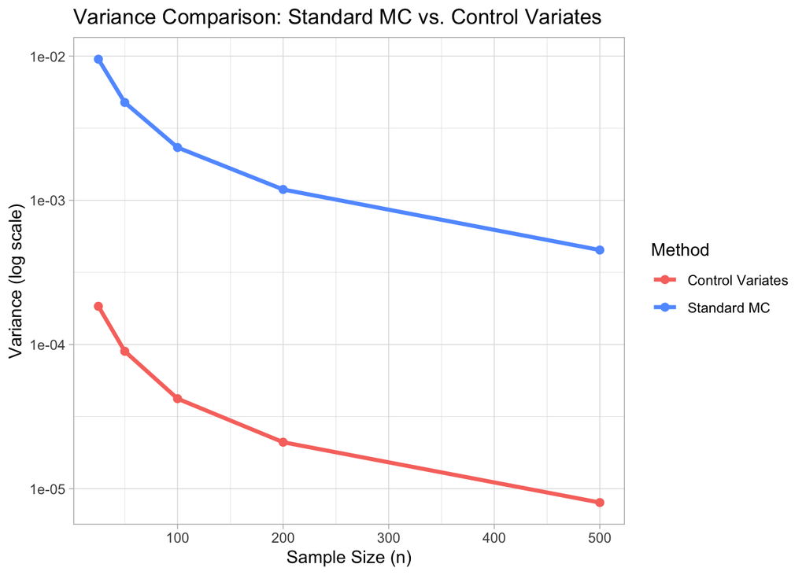

```r
mc_comparison <- function(n, n_rep = 1000) {
  set.seed(123)

  # Storage for estimates
  est_standard <- numeric(n_rep)
  est_cv <- numeric(n_rep)

  for (i in 1:n_rep) {
    U <- runif(n)
    f_vals <- f_target(U)
    g_vals <- g_control(U)

    # Standard Monte Carlo
    est_standard[i] <- mean(f_vals)

    # Control variate
    c_opt <- cov(f_vals, g_vals) / var(g_vals)
    est_cv[i] <- mean(f_vals) - c_opt * (mean(g_vals) - true_g)
  }

  tibble(
    method = c("Standard MC", "Control Variates"),
    bias = c(mean(est_standard) - true_f, mean(est_cv) - true_f),
    variance = c(var(est_standard), var(est_cv)),
    mse = c(mean((est_standard - true_f)^2), mean((est_cv - true_f)^2))
  )
}

set.seed(42)
df_comparison <- tibble(n = c(25, 50, 100, 200, 500)) %>%
  mutate(results = map(n, mc_comparison)) %>%
  unnest(results)

(p_variance <- df_comparison %>%
  ggplot(aes(n, variance, color = method)) +
  geom_line(size = 1.2) +
  geom_point(size = 2) +
  scale_y_log10() +
  scale_color_manual(values = c("#f8766d", "#619cff")) +
  labs(x = "Sample Size (n)",
       y = "Variance (log scale)",
       title = "Variance Comparison: Standard MC vs. Control Variates",
       color = "Method") +
  theme_light())
```

# 4 Convergence Analysis

Let’s analyze how both methods converge to the true value:

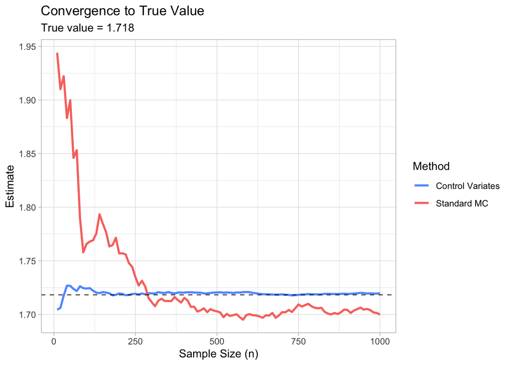

```r
convergence_analysis <- function(max_n = 1000) {
  set.seed(42)
  U <- runif(max_n)
  f_vals <- f_target(U)
  g_vals <- g_control(U)

  # Create cumulative estimates
  n_seq <- seq(10, max_n, by = 10)

  est_standard <- numeric(length(n_seq))
  est_cv <- numeric(length(n_seq))

  for (i in seq_along(n_seq)) {
    n <- n_seq[i]
    f_sub <- f_vals[1:n]
    g_sub <- g_vals[1:n]

    # Standard MC
    est_standard[i] <- mean(f_sub)

    # Control variate
    c_opt <- cov(f_sub, g_sub) / var(g_sub)
    est_cv[i] <- mean(f_sub) - c_opt * (mean(g_sub) - true_g)
  }

  tibble(
    n = n_seq,
    standard = est_standard,
    control_variate = est_cv
  )
}

df_conv <- convergence_analysis()

(p_convergence <- df_conv %>%
  pivot_longer(-n, names_to = "method", values_to = "estimate") %>%
  ggplot(aes(n, estimate, color = method)) +
  geom_line(size = 1) +
  geom_hline(yintercept = true_f, linetype = "dashed", color = "black", alpha = 0.7) +
  scale_color_manual(values = c("#619cff", "#f8766d"),
                     labels = c("Control Variates", "Standard MC")) +
  labs(x = "Sample Size (n)",
       y = "Estimate",
       title = "Convergence to True Value",
       subtitle = sprintf("True value = %.3f", true_f),
       color = "Method") +
  theme_light())
```

# 5 Theoretical Variance Reduction

The theoretical variance reduction factor is:
$$\frac{\text{Var}(\hat{I}_{CV})}{\text{Var}(\hat{I}_{standard})}
= 1 - \rho^2$$

where $\rho$ is the correlation between $f(U)$ and $g(U)$.

```r
# Calculate theoretical correlation and variance reduction
set.seed(42)
U_theory <- runif(10000)
f_theory <- f_target(U_theory)
g_theory <- g_control(U_theory)

correlation <- cor(f_theory, g_theory)
theoretical_reduction <- 1 - correlation^2

cat("Correlation between f(U) and g(U):", round(correlation, 3), "\n")
```

```
## Correlation between f(U) and g(U): 0.992
```

```r
cat("Theoretical variance reduction factor:", round(theoretical_reduction, 3), "\n")
```

```
## Theoretical variance reduction factor: 0.016
```

```r
cat("Expected variance reduction:", round((1 - theoretical_reduction) * 100, 1), "%\n")
```

```
## Expected variance reduction: 98.4 %
```

The control variates method achieves significant variance reduction because $e^x$ and $x$ are highly positively correlated on $[0,1]$. This strong correlation allows the control variate to effectively “correct” for the randomness in the standard Monte Carlo estimate, leading to more precise integration results with the same computational cost.